# Feature-based Interpretation of spectral clustering solutions for mixed data

RSS International Conference 2026 · Bournemouth

Alfonso Iodice D’Enza, Cristina Tortora and Francesco Palumbo

## Outline

**Spectral clustering in a nutshell**  
From pairwise distances to a graph partition

**Feature-aware distances for mixed data**  
Which numerical and categorical differences enter the graph?

**Association- and interaction-aware construction**  
Encoding redundancy and continuous–categorical structure

**Synthetic evidence and interpretation**  
What spectral clustering can recover from each representation

**cluster analysis**

the general aim is to find homogeneous groups of observations

- observations from the same group are similar to each other
- observations from different groups are not similar to each other
- multiple clustering approaches exist

**clustering approaches**

- If a cluster structure does underlie the observations at hand, any approach will work

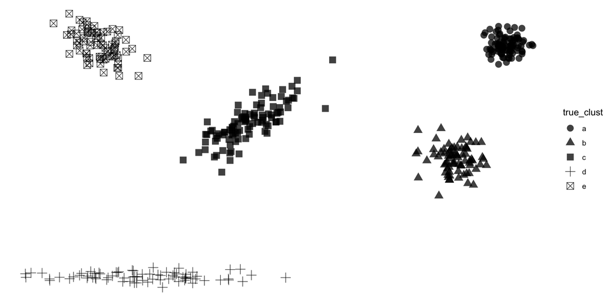

**clustering approaches**

partitioning<sup>1</sup>

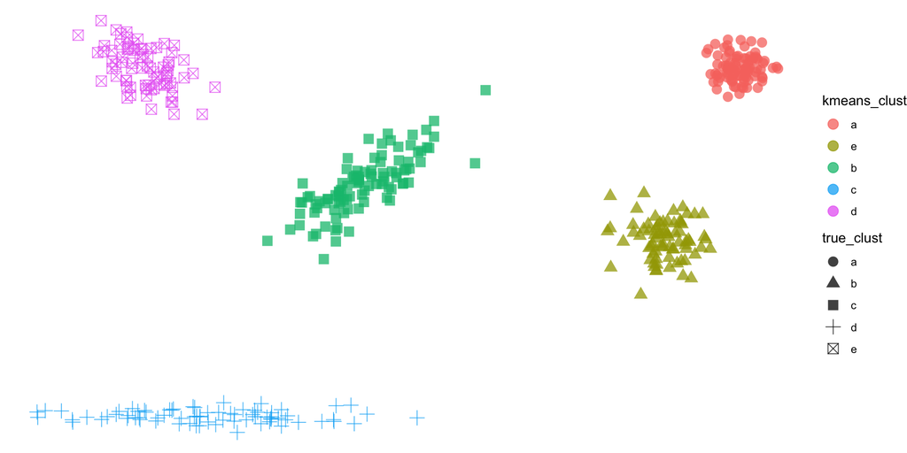

[^1]: MacQueen’s $K$-means; MacQueen (1967)

**clustering approaches**

agglomerative<sup>1</sup>

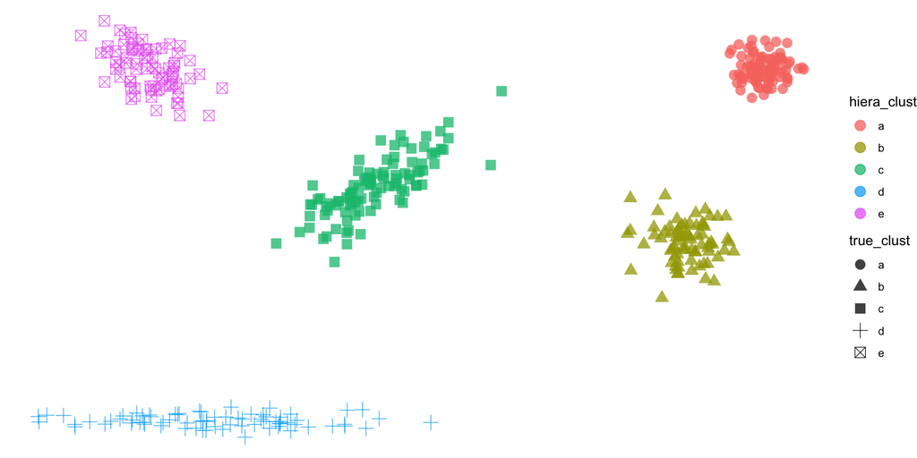

[^2]: Kaufman & Rousseeuw (2009)

**clustering approaches**

model-based<sup>1</sup>

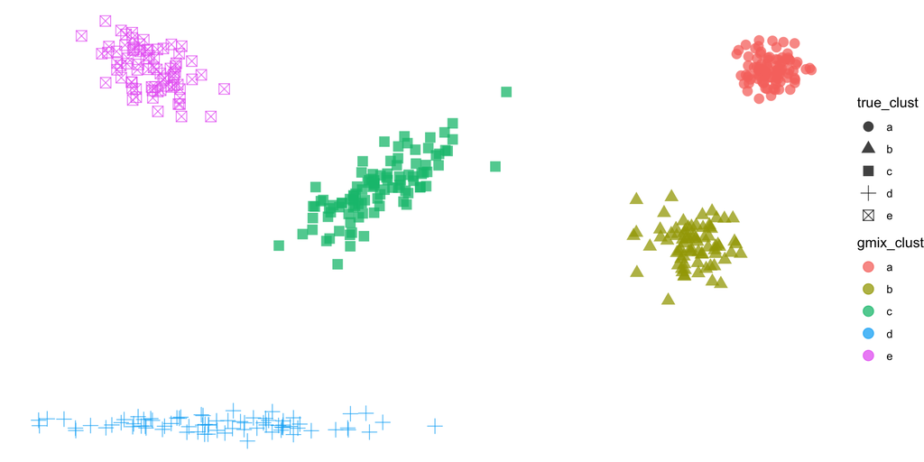

[^3]: McLachlan & Basford (1988)

**clustering approaches**

density-based<sup>1</sup>

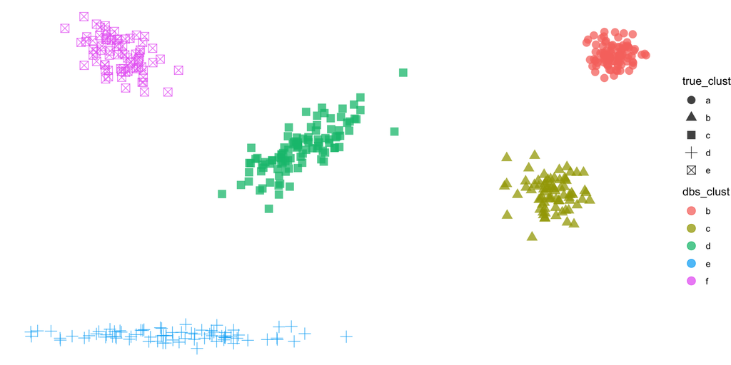

[^4]: DBSCAN; Ester, Kriegel, Sander, Xu, et al. (1996)

**clustering approaches**

spectral<sup>1</sup>

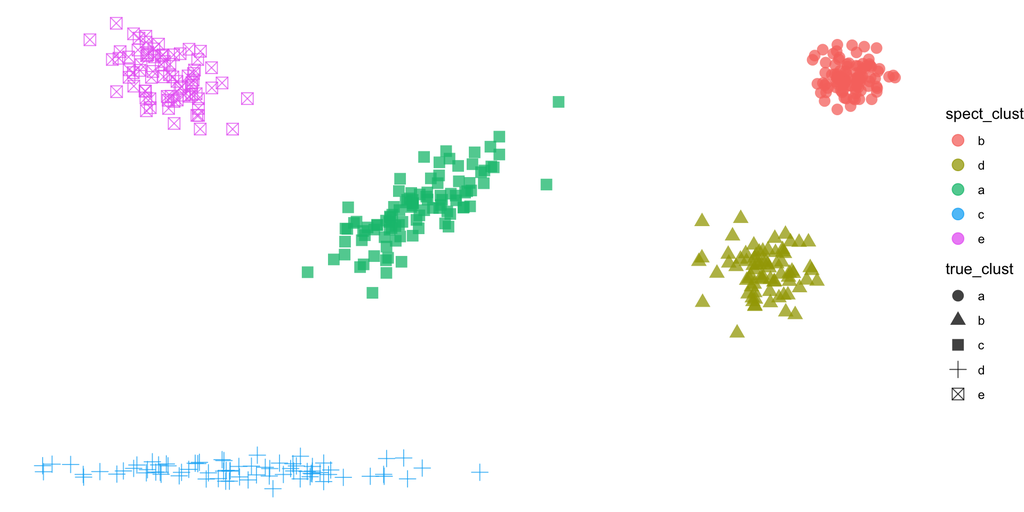

[^5]: NJW; Ng, Jordan, & Weiss (2001)

**clustering approaches**

If a cluster structure does underlie the observations at hand, any approach will work

OR NOT?

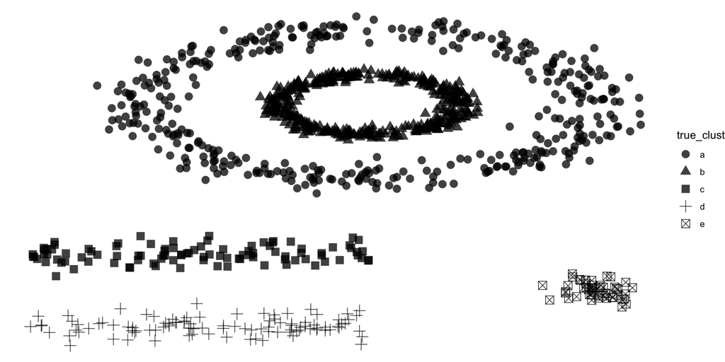

**clustering approaches**

partitioning (Kmeans)

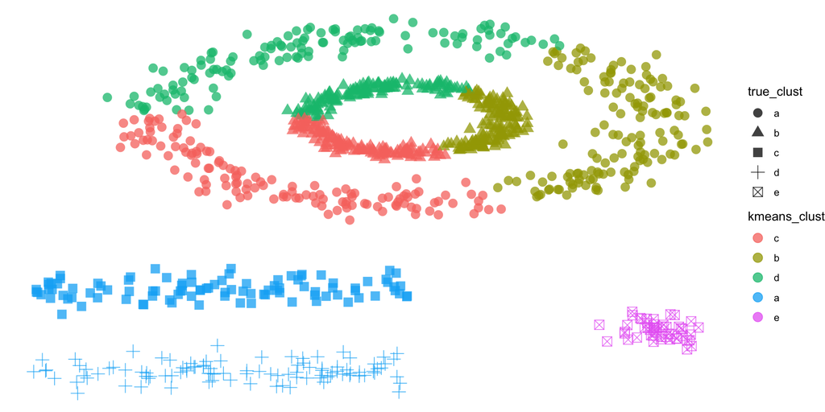

**clustering approaches**

agglomerative

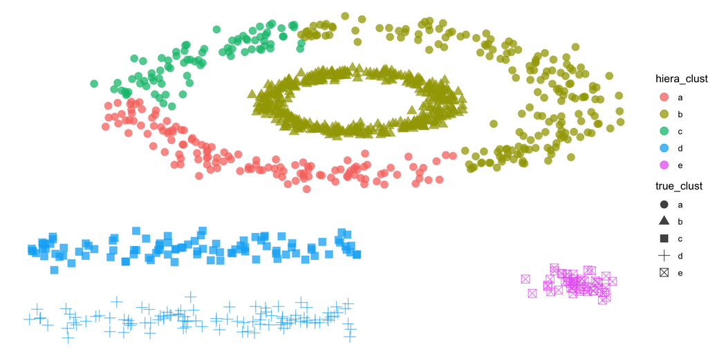

**clustering approaches**

model-based (GMM)

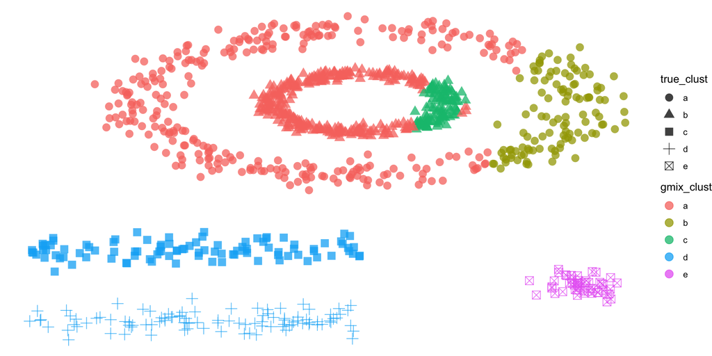

**clustering approaches**

density-based (dbscan)

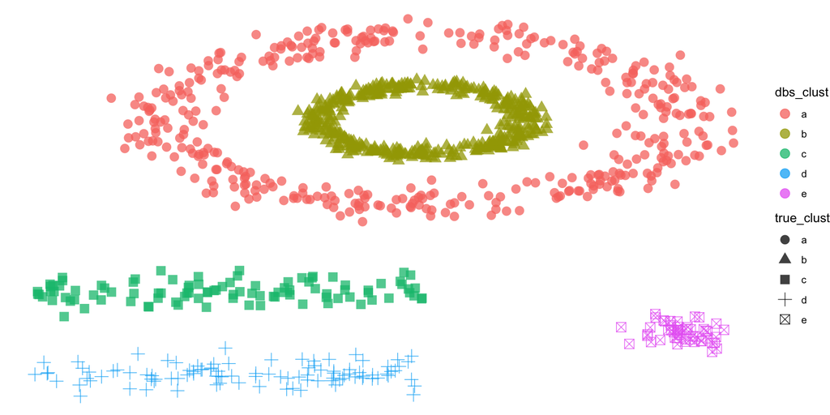

**clustering approaches**

spectral

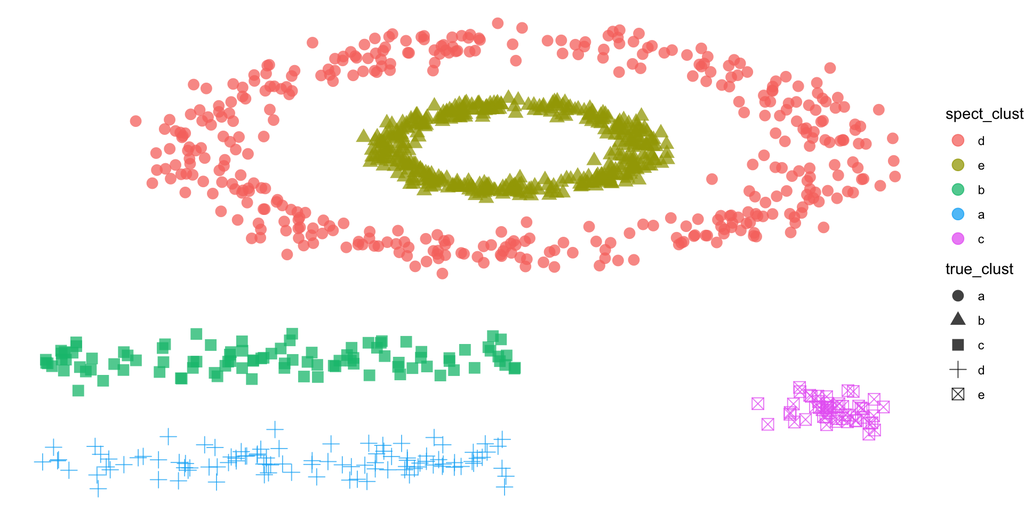

# spectral clustering in a nutshell

## Spectral clustering: a graph partitioning problem

**Graph representation**

Represent the data matrix ${\bf X}$ as a graph and cut it into $K$ groups, or clusters.

- observations are vertices;
- pairwise similarities are edge weights;
- large ${w}_{i\ell}$ indicates that observations $i$ and $\ell$ should remain connected.

### the distance determines the graph that is available to partition

## From distances to affinities

Start from the $I\times I$ pairwise distance matrix ${\bf D}$ and construct

$${\bf A}
=
\exp\left(-\frac{{\bf D}^{2}}{2\sigma^{2}}\right),
\qquad a_{ii}=0.$$

**Affinity**

The elements ${a}_{i\ell}$ are high when observations $i$ and $\ell$ are close under the chosen distance.

**Neighbourhood scale**

The parameter $\sigma$ controls which pairwise relationships remain visible in the graph.

## Making the graph easy to cut

An approximate solution to the graph partitioning problem<sup>1</sup>:

**Normalized graph Laplacian**

$${\bf L}
=
{\bf D}_{r}^{-1/2}
{\bf A}
{\bf D}_{r}^{-1/2}
=
{\bf Q}{\Lambda}{\bf Q}^{\sf T},$$

where ${\bf D}_{r}=\operatorname{diag}({\bf r})$, ${\bf r}={\bf A}{\bf 1}$, and ${\bf 1}$ is an $I$-dimensional vector of ones.

**Spectral embedding**

Apply $K$-means to the rows of ${\bf \widetilde Q}$, containing the first $K$ eigenvectors of ${\bf L}$.

[^6]: Ng et al. (2001)

## Why spectral clustering?

Spectral clustering works on the connectivity encoded by the graph and can recover non-convex structure.

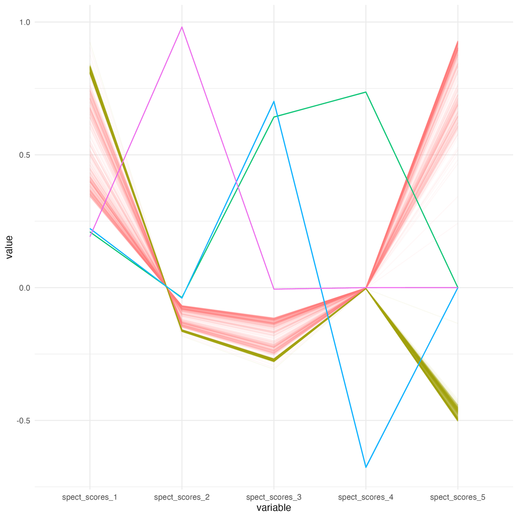

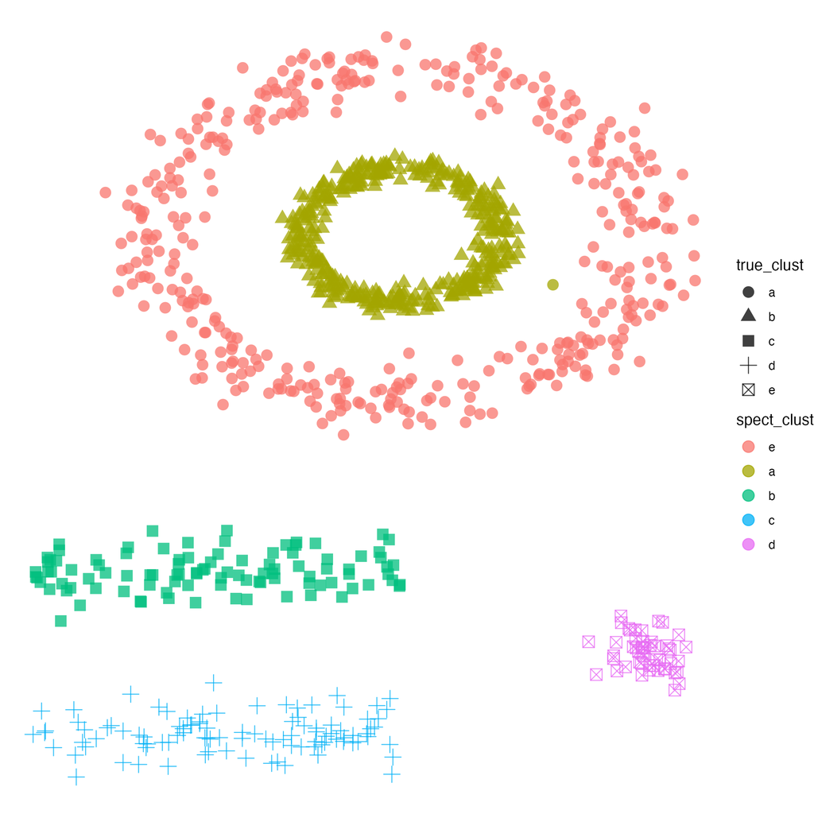

# feature-aware distances for mixed data

## Mixed-data setup

**A mixed data set**

- $I$ observations described by $Q$ variables;
- $Q_n$ numerical variables and $Q_c$ categorical variables;
- the $I\times Q$ data matrix is column-wise partitioned:

$${\bf X}=\left[{\bf X}_{n},{\bf X}_{c}\right].$$

A general mixed distance between observations $i$ and $\ell$ is

$$\begin{aligned}
d\left(\mathbf{x}_i,\mathbf{x}_\ell\right)
&=
\sum_{j_n=1}^{Q_n}
w_{j_n}\delta^n_{j_n}
\left(\mathbf{x}^n_i,\mathbf{x}^n_\ell\right)
\\
&\quad+
\sum_{j_c=1}^{Q_c}
w_{j_c}\delta^c_{j_c}
\left(\mathbf{x}^c_i,\mathbf{x}^c_\ell\right).
\end{aligned}$$

## The numerical geometry suggests two groups

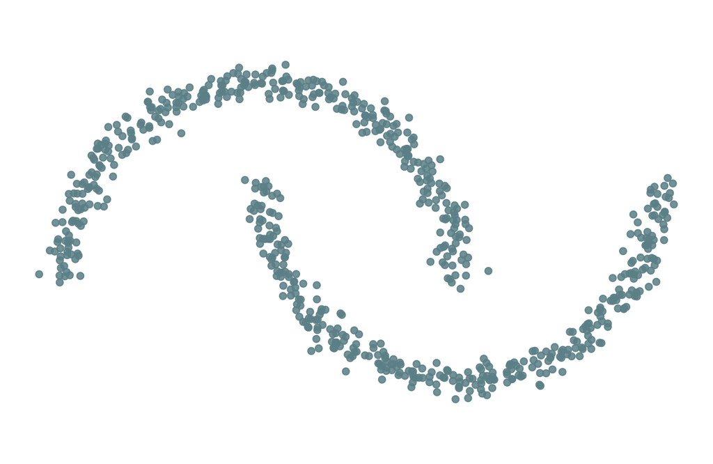

2

### connected shapes

A numerical distance can recover the **upper** and **lower** moon.

**Geometry alone**

There is no preferred subdivision within either moon.

## One factor is structured; the other is deliberately neutral

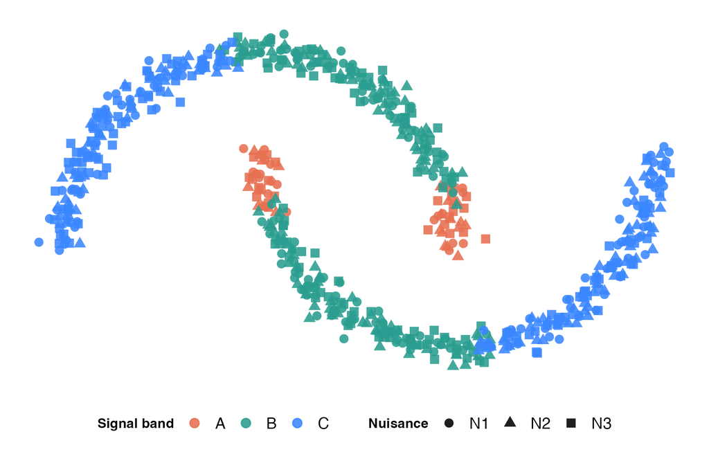

**Signal band**

- colour: $A,B,C$
- unequal arc lengths: $10\%,45\%,45\%$
- repeated on both moons

**Nuisance factor**

- shape: $N_1,N_2,N_3$
- balanced within every band
- spatially random

### only the signal factor has a systematic relationship with the numerical geometry

## The target is the moon **AND** the signal category

$$\text{cluster}
=
\text{moon}\times\text{band}$$

The desired partition contains six groups:

$$\begin{aligned}
&U\!A,\ U\!B,\ U\!C,\\
&L\!A,\ L\!B,\ L\!C.
\end{aligned}$$

**The six-way intersection**

Moon alone gives two groups. Band alone gives three.

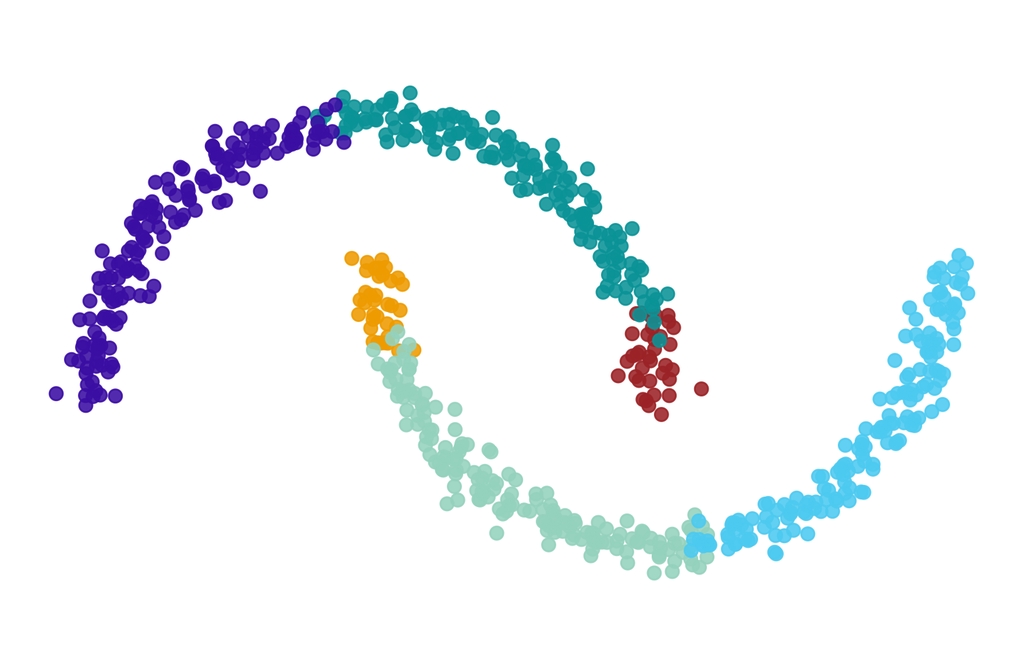

## Without interaction, the graph follows geometry

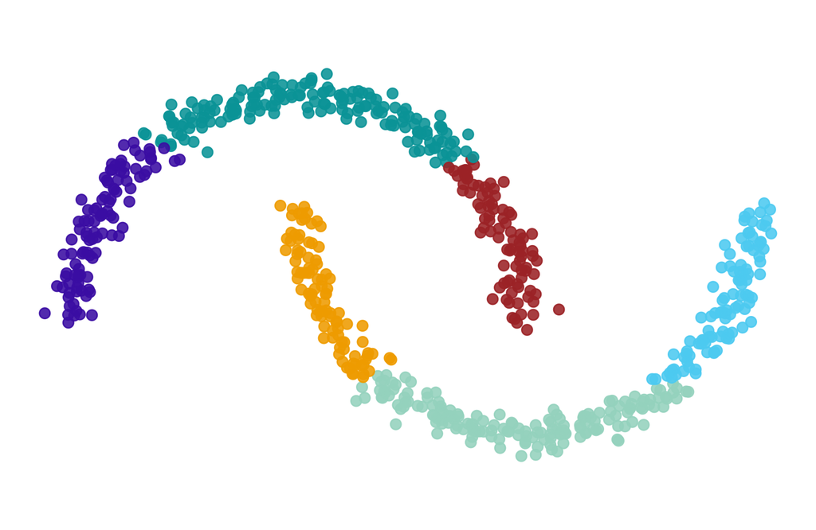

ARI = 0.490

Spectral clustering is asked for $K=6$, but the graph does not know where $A$, $B$, and $C$ change.

**The wrong boundaries**

The moons are subdivided according to numerical geometry—not the signal factor.

## With interaction, the graph recovers the six intersections

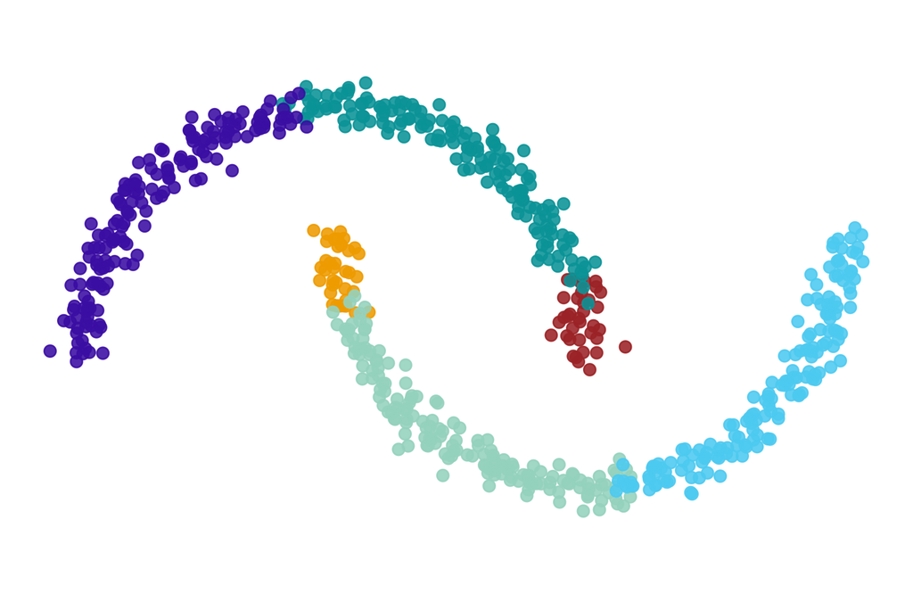

ARI = 1.000

The numerical distance preserves the two moons.

$\Delta_{\mathrm{int}}$ adds barriers at the $A/B/C$ boundaries.

**Exact recovery**

The graph now encodes the required **moon AND category** structure.

## The distance determines what spectral clustering can recover

$$\begin{aligned}
&\text{numerical geometry}
\;+\;
\text{categorical association}\\[0.25em]
&\qquad+\;
\text{cross-type interaction}
\;\Longrightarrow\;
\text{graph structure}
\end{aligned}$$

If clusters are defined jointly by numerical and categorical information,  
the distance must make that joint structure visible **before** the graph is partitioned.

### this motivates an interaction-aware construction for mixed-data dissimilarities

## Independence-based distances

**Independence-based pairwise distance**

No inter-variable relations are considered.

- continuous variables: **Euclidean** or **Manhattan** distances;
- categorical variables: **Hamming** / matching distance, among many others;
- mixed data: **Gower** dissimilarity index.

**Beyond commensurability**

Commensurability makes variable contributions comparable across **scales** and data **types**<sup>1</sup>.

If variables are correlated or associated, shared information may still enter the distance repeatedly: **redundancy**.

[^7]: van de Velden, Iodice D’Enza, Markos, & Cavicchia (2026)

## The graph inherits the feature representation

**Scale and type**

Are contributions comparable across measurement scales and data types?

**Association**

Is shared information within the numerical or categorical block counted repeatedly?

**Interaction**

Do numerical features make some categorical distinctions more meaningful than others?

### feature-based interpretation starts with the components used to construct ${\bf D}$

# association-based distances

## Continuous features: Mahalanobis distance

**Association-aware continuous component**

Let ${\bf X}_{n}$ be an $I\times Q_n$ matrix and let ${\bf S}$ be its sample covariance matrix. The Mahalanobis distance matrix is

$${\bf D}_{mah}
=
\left[
\operatorname{diag}({\bf G}){\bf 1}^{\sf T}
+
{\bf 1}\operatorname{diag}({\bf G})^{\sf T}
-
2{\bf G}
\right]^{\odot 1/2},$$

where

$${\bf G}
=
({\bf C}{\bf X}_{n})
{\bf S}^{-1}
({\bf C}{\bf X}_{n})^{\sf T},
\qquad
{\bf C}
=
{\bf I}-\frac{1}{I}{\bf 1}{\bf 1}^{\sf T}.$$

### correlations are represented through ${\bf S}^{-1}$ rather than counted as separate independent directions

## Categorical features: the delta framework

Let ${\bf X}_{c}$ be an $I\times Q_c$ categorical data matrix, and let

$${\bf Z}=\left[{\bf Z}_{1},\ldots,{\bf Z}_{Q_c}\right]$$

be its one-hot encoding.

$${\bf D}_{c}
=
{\bf Z}{\Delta}{\bf Z}^{\sf T},
\qquad
\Delta
=
\operatorname{bdiag}
\left(
\Delta_1,\ldots,\Delta_{Q_c}
\right).$$

Setting the category-dissimilarity blocks $\Delta_j$ determines the categorical distance measure<sup>1</sup>.

### category-level distinctions are translated into observation-level distances

[^8]: van de Velden, Iodice D’Enza, Markos, & Cavicchia (2024)

## From co-occurrences to conditional profiles

The empirical co-occurrence matrix is

$${\bf P}
=
\frac{1}{I}{\bf Z}^{\sf T}{\bf Z}.$$

Its off-diagonal blocks contain joint proportions between categorical variables.

Let

$${\bf P}_{z}
=
{\bf P}\odot{\bf I}_{Q^*}.$$

The block matrix

$${\bf R}
=
{\bf P}_{z}^{-1}
\left(
{\bf P}-{\bf P}_{z}
\right)$$

contains conditional profiles across variables.

## Total variation distance between categories

Let ${\bf r}^{ji}_a$ and ${\bf r}^{ji}_b$ be rows of the $(j,i)$th off-diagonal block of ${\bf R}$.

**Association-aware categorical component**

For categories $a$ and $b$ of variable $j$,

$$\begin{aligned}
\delta^{j}_{tvd}(a,b)
&=
\sum_{i\neq j}^{Q_c}
w_{ji}
\Phi^{ji}
\left(
{\bf r}^{ji}_{a},
{\bf r}^{ji}_{b}
\right)
\\
&=
\sum_{i\neq j}^{Q_c}
w_{ji}
\left[
\frac{1}{2}
\sum_{\ell=1}^{q_i}
\left|
{\bf r}^{ji}_{a\ell}
-
{\bf r}^{ji}_{b\ell}
\right|
\right],
\end{aligned}$$

with $w_{ji}=1/(Q_c-1)$ under equal weighting<sup>1</sup>.

[^9]: Le & Ho (2005)

## From category dissimilarities to ${\bf D}_{tvd}$

Collect the category-dissimilarity matrices in

$$\Delta^{(tvd)}
=
\operatorname{bdiag}
\left(
\Delta^{(tvd)}_1,\ldots,\Delta^{(tvd)}_{Q_c}
\right).$$

Then

$$\begin{aligned}
{\bf D}_{tvd}
&=
{\bf Z}
\Delta^{(tvd)}
{\bf Z}^{\sf T}
\\
&=
\sum_{j=1}^{Q_c}
{\bf Z}_j
\Delta^{(tvd)}_j
{\bf Z}_j^{\sf T}.
\end{aligned}$$

### categorical mismatches are weighted by how differently their categories relate to the other categorical features

## Association-aware mixed representation

Within each variable block:

**Numerical block**

${\bf D}_{mah}$ accounts for covariance and redundancy among continuous variables.

**Categorical block**

${\bf D}_{tvd}$ accounts for associations among categorical variables.

$${\bf D}_{mix}^{(assoc)}
=
{\bf D}_{mah}
+
{\bf D}_{tvd}.$$

### within-block structure is represented, but cross-type structure is still missing

# interaction-aware extensions

## Cross-type interactions

Association-aware distances account for relations

- among continuous variables;
- among categorical variables.

**Cross-type structure**

In mixed data, categorical differences may be meaningful because they are reflected in the continuous variables.

### the next step is to make the distance interaction-aware

## How to measure interactions<sup>1</sup>

Define $\Delta^{int}$ to encode continuous–categorical interactions and augment $\Delta^{tvd}$:

$$\widetilde{\Delta}
=
(1-\alpha)\Delta^{tvd}
+
\alpha\Delta^{int},
\qquad
\alpha=\frac{1}{Q_c}.$$

The mixed dissimilarity becomes

$${\bf D}_{mix}^{(int)}
=
{\bf D}_{mah}
+
{\bf D}_{cat}^{(int)},
\qquad
{\bf D}_{cat}^{(int)}
=
{\bf Z}\widetilde{\Delta}{\bf Z}^{\sf T}.$$

[^10]: Iodice D’Enza, Tortora, & Palumbo (2026)

## What is $\Delta^{int}$?

The entry $\delta_{int}^{j}(a,b)$ measures how much the continuous variables help discriminate between observations choosing category $a$ and those choosing category $b$ for categorical variable $j$.

**Category-pair classification problem**

For each pair $(a,b)$:

- use the continuous variables as predictors;
- classify observations belonging to categories $a$ and $b$;
- use a nearest-neighbour rule in the continuous space.

## Computing $\Delta^{int}_{j}$

For each categorical variable $j$ and each category pair $(a,b)$:

1. use ${\bf D}_{mah}$ to identify neighbours among observations belonging to $a$ or $b$;
2. consider a proportion of neighbours, say $\pi_{nn}=0.1$;
3. classify observations using a prior-corrected decision rule;
4. compute balanced accuracy.

$$\operatorname{BAcc}^{j}(a,b)
=
\frac{1}{2}
\left[
\operatorname{TPR}^{j}_{a}(a,b)
+
\operatorname{TPR}^{j}_{b}(a,b)
\right].$$

Map predictive performance onto a non-negative separability scale:

$$\delta^{j}_{int}(a,b)
=
\max\left\{
0,\,
2\operatorname{BAcc}^{j}(a,b)-1
\right\}
\in[0,1].$$

### $0$ means chance-level or worse; $1$ means perfect separation

## Computing $\Delta^{int}_{j}$

For categorical variable $j$ with $q_j$ categories, compute  
$\frac{q_j(q_j -1)}{2}$ category-pair quantities.

$$\Delta_{int} =
\begin{pmatrix}
0 & \cdot & \cdot & \cdot \\
\cdot & 0 & \cdot & \cdot \\
\cdot & \cdot & 0 & \cdot\\
\cdot & \cdot & \cdot & 0
\end{pmatrix}$$

## Computing $\Delta^{int}_{j}$

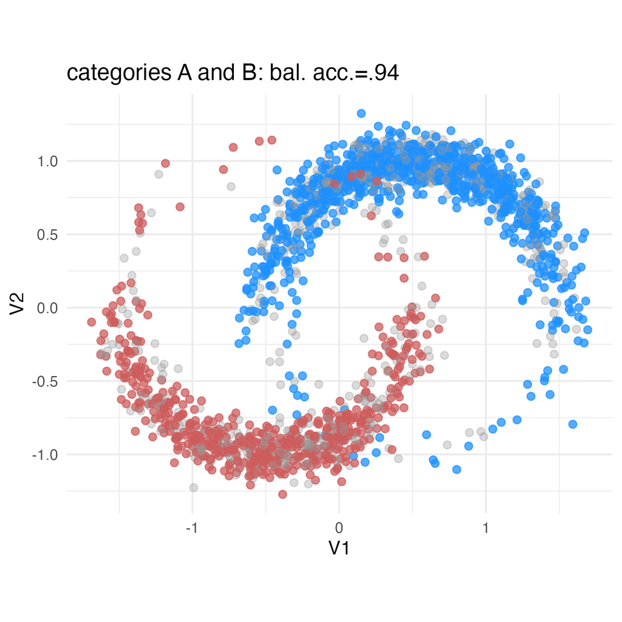

$$\Delta_{int} =
\begin{pmatrix}
0 & \color{#E76F51}{0.94} & \cdot & \cdot \\
\color{#E76F51}{0.94} & 0 & \cdot & \cdot \\
\cdot & \cdot & 0 & \cdot\\
\cdot & \cdot & \cdot & 0
\end{pmatrix}$$

## Computing $\Delta^{int}_{j}$

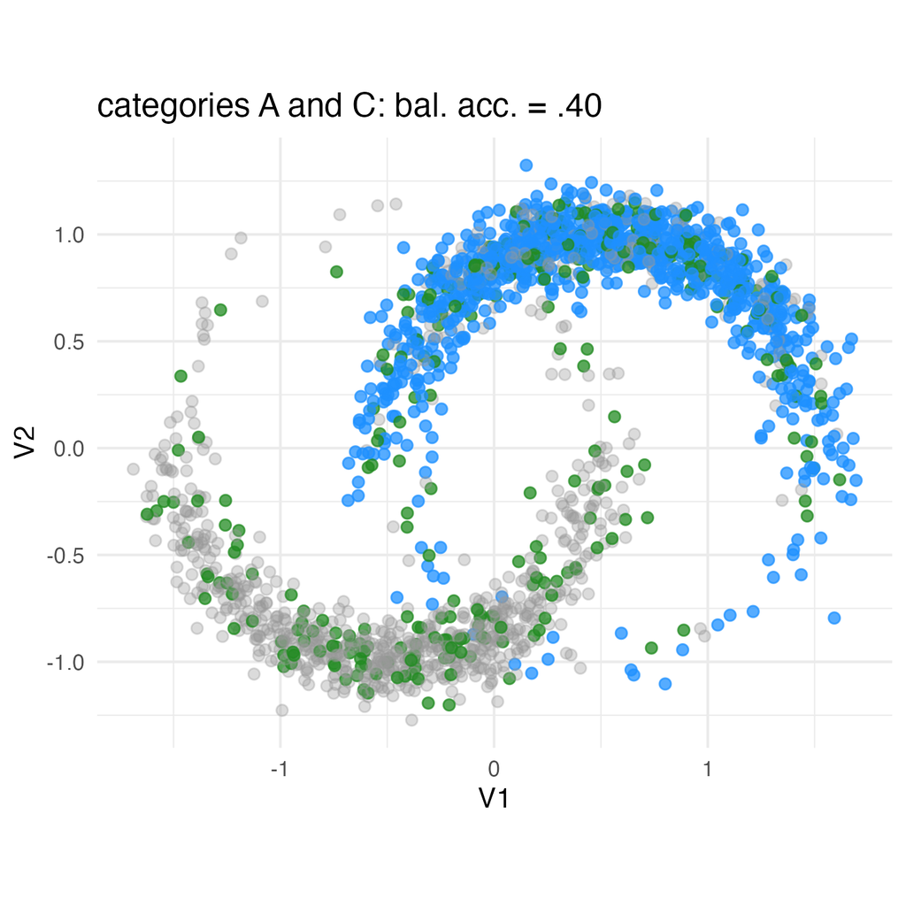

$$\Delta_{int} =
\begin{pmatrix}
0 & 0.94 & \color{#E76F51}{0.40} & \cdot \\
0.94 & 0 & \cdot & \cdot \\
\color{#E76F51}{0.40} & \cdot & 0 & \cdot\\
\cdot & \cdot & \cdot & 0
\end{pmatrix}$$

## Computing $\Delta^{int}_{j}$

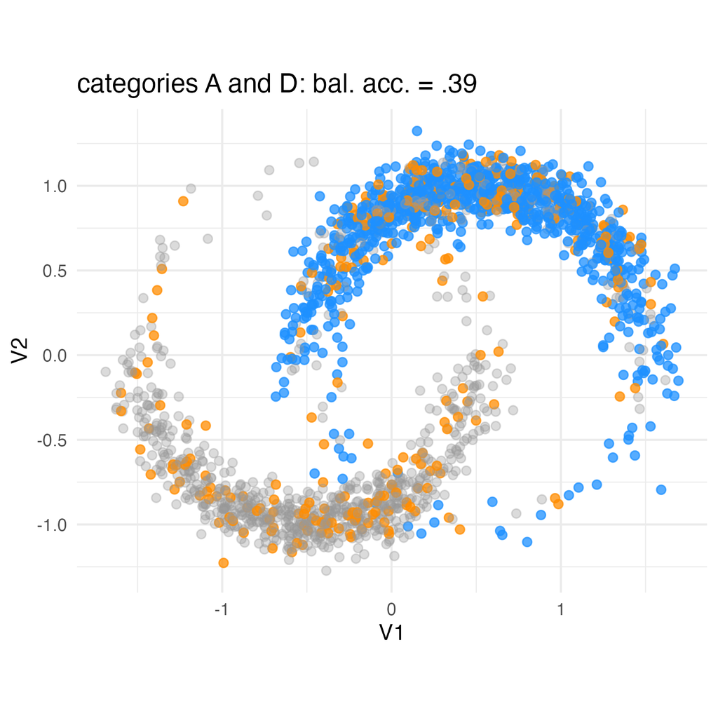

$$\Delta_{int} =
\begin{pmatrix}
0 & 0.94 & 0.40 & \color{#E76F51}{0.39} \\
0.94 & 0 & \cdot & \cdot \\
0.40 & \cdot & 0 & \cdot\\
\color{#E76F51}{0.39} & \cdot & \cdot & 0
\end{pmatrix}$$

## Computing $\Delta^{int}_{j}$

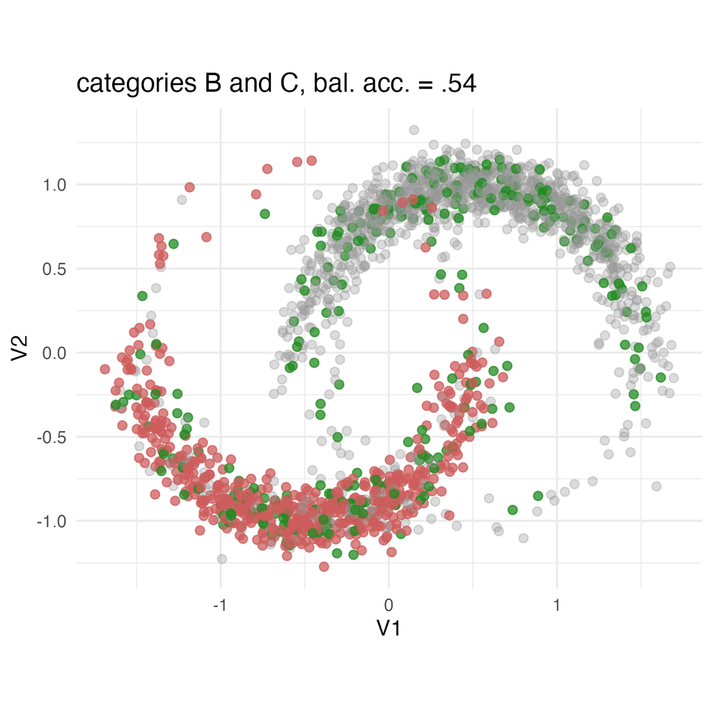

$$\Delta_{int} =
\begin{pmatrix}
0 & 0.94 & 0.40 & 0.39 \\
0.94 & 0 & \color{#E76F51}{0.54} & \cdot \\
0.40 & \color{#E76F51}{0.54} & 0 & \cdot \\
0.39 & \cdot & \cdot & 0
\end{pmatrix}$$

## Computing $\Delta^{int}_{j}$

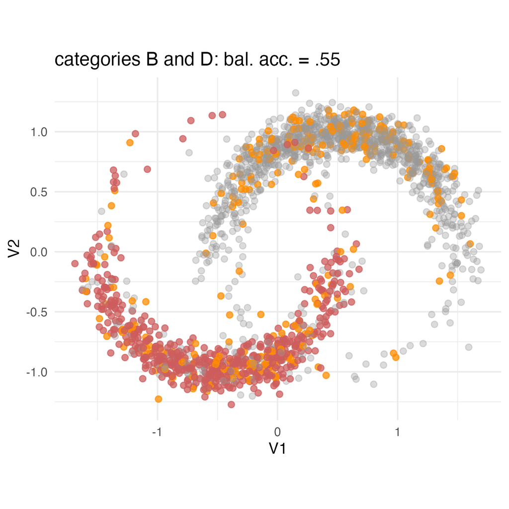

$$\Delta_{int} =
\begin{pmatrix}
0 & 0.94 & 0.40 & 0.39 \\
0.94 & 0 & 0.54 & \color{#E76F51}{0.55} \\
0.40 & 0.54 & 0 & \cdot \\
0.39 & \color{#E76F51}{0.55} & \cdot & 0
\end{pmatrix}$$

## Computing $\Delta^{int}_{j}$

[figure not shown]

$$\Delta_{int} =
\begin{pmatrix}
0 & 0.94 & 0.40 & 0.39 \\
0.94 & 0 & 0.54 & 0.55 \\
0.40 & 0.54 & 0 & \color{#E76F51}{0} \\
0.39 & 0.55 & \color{#E76F51}{0} & 0
\end{pmatrix}$$

### summarize category-pair separability in the continuous space

## Back to the motivating example

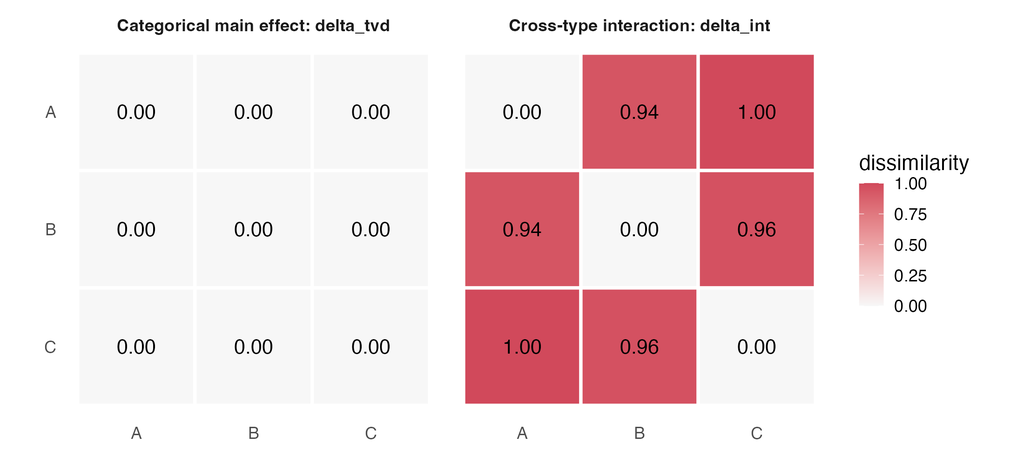

$$\Delta_{\mathrm{tvd}}=0$$

Band and nuisance are independent.

$$\delta^{\mathrm{int}}(a,b)
=
\max\{0,\ 2\,\mathrm{BAcc}(a,b)-1\}$$

Numerical neighbours discriminate every band pair.

$\delta^{\mathrm{int}}_{AB}=0.94\qquad \delta^{\mathrm{int}}_{AC}=1.00\qquad \delta^{\mathrm{int}}_{BC}=0.96$

## A feature-based decomposition of pairwise dissimilarity

For observations $i$ and $\ell$,

$$\begin{aligned}
d_{mix}^{(int)}(i,\ell)
&=
d_{mah}
\left(
{\bf x}_{i_n},
{\bf x}_{\ell_n}
\right)
\\
&\quad+
\sum_{j=1}^{Q_c}
\left[
(1-\alpha)
\delta^{j}_{tvd}
\left(
x_{ij_c},
x_{\ell j_c}
\right)
+
\alpha
\delta^{j}_{int}
\left(
x_{ij_c},
x_{\ell j_c}
\right)
\right].
\end{aligned}$$

### every graph edge is built from continuous association, categorical association, and cross-type interaction components

## The additive construction is coherent

Define the maximum-normalised continuous and categorical kernels:

$$\overline K_{\mathrm n}(i,\ell)
=
\exp
\left\{
-
d_{mah}
\left(
{\bf x}_{i_n},
{\bf x}_{\ell_n}
\right)
\right\},$$

$$\overline K_{\mathrm c}^{(int)}(i,\ell)
=
\exp
\left\{
-
d_{\mathrm c}^{(int)}
\left(
{\bf x}_{i_c},
{\bf x}_{\ell_c}
\right)
\right\}.$$

Their product satisfies

$$-\log
\left[
\overline K_{\mathrm n}(i,\ell)
\overline K_{\mathrm c}^{(int)}(i,\ell)
\right]
=
d_{mix}^{(int)}(i,\ell).$$

## From feature relations to a spectral solution

**1. Features**

Numerical, categorical, and cross-type relations

$\rightarrow$

**2. Distance**

${\bf D}_{mah}+{\bf Z}\widetilde{\Delta}{\bf Z}^{\sf T}$

$\rightarrow$

**3. Graph**

Affinities, spectral embedding, and partition

### interpreting the solution means tracing which feature relations made observations close

# synthetic experiments

## Simulation 1: associated mixed variables

**General design**

**Feature structure**

- correlated numerical variables;
- associated categorical variables;
- categorical variables depending on numerical variables;
- an additional noise scenario.

## Simulation 1: variable composition

Four mixed-data scenarios:

1. $Q_n=15$, $Q_c=15$;
2. $Q_n=10$, $Q_c=20$;
3. $Q_n=20$, $Q_c=10$;
4. $Q_n=10$, $Q_c=10$, plus noise variables.

### the design induces numerical correlations, categorical associations, and numerical–categorical dependence

## Simulation 1: results

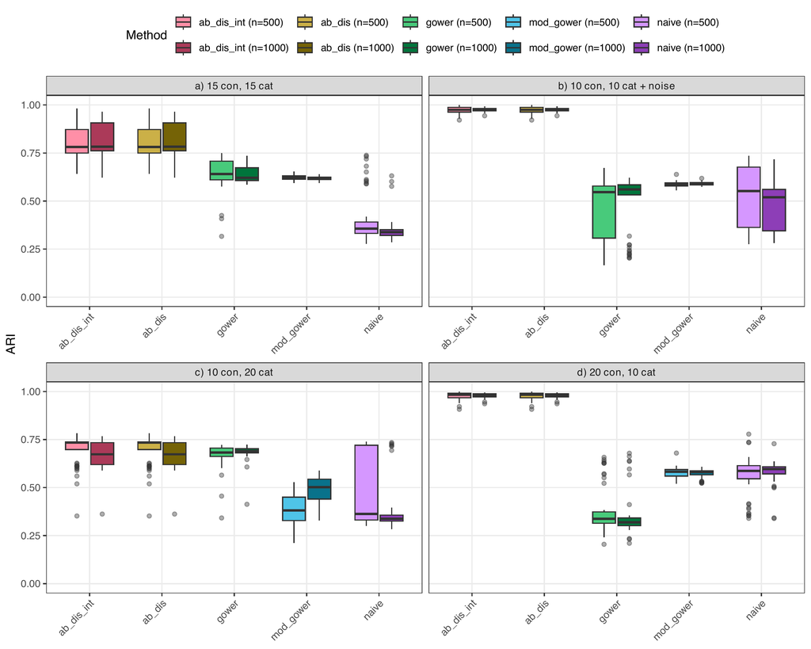

- Association-based distances are generally the most accurate.
- When continuous variables dominate, association-based distances achieve almost perfect recovery.
- Standard mixed-data distances are more sensitive to variable composition and noise.

## Simulation 2: interaction-driven clusters

**Design**

- $I=500$ and $I=1000$;
- six continuous and three categorical variables;
- $V_4,V_5,V_6$ generated independently from $N(0,1)$;
- $V_1,V_2,V_3$ generated conditionally on $C_1$ and $C_2$.

**Main feature**

The clusters are not defined by the continuous variables alone or the categorical variables alone.

They are defined by their **cross-type interaction**.

### this is the setting where $\Delta^{int}$ should matter

## Simulation 2: results

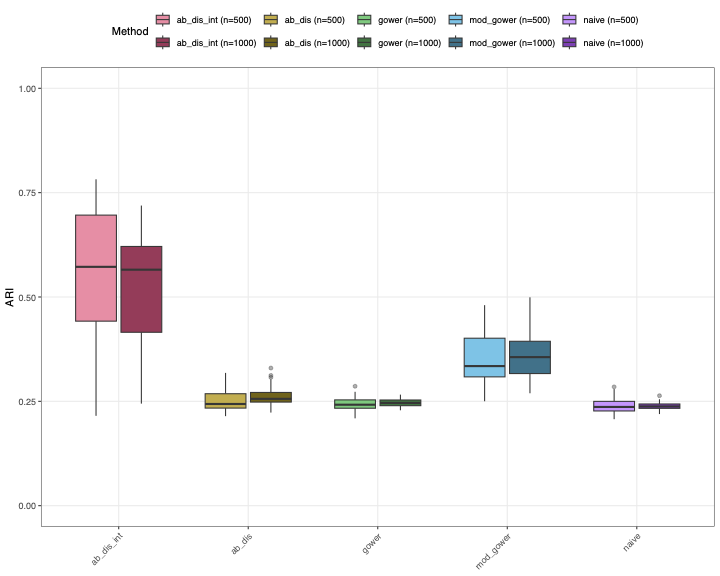

# interpretation and conclusions

## Reading a spectral solution through its features

**${\bf D}_{mah}$**

Which numerical differences remain after accounting for covariance?

**$\Delta^{tvd}$**

Which categorical distinctions are supported by their relations with other categorical features?

**$\Delta^{int}$**

Which categorical distinctions are expressed in the continuous feature space?

### these components explain the representation supplied to spectral clustering—not a post-hoc relabelling of the clusters

## What the experiments support

**Association structure matters**

Mahalanobis and TVD-based components account for redundancy within the numerical and categorical blocks.

**Cross-type interactions must be encoded**

$\Delta^{int}$ translates category separability in the numerical space into categorical dissimilarities.

**The distance determines what spectral clustering can recover**

The simulations favour association-aware distances and show a clear gain from $\Delta^{int}$ when clusters are interaction-driven.

## Main message

A spectral clustering solution is only as informative as the pairwise representation supplied to it.

### For mixed data, feature-based interpretation requires distances that make scale, association, and cross-type interaction explicit.

## Main references

Iodice D’Enza, A., Tortora, C., & Palumbo, F. (2026). Association-based spectral clustering for mixed data with cross-type interactions. *Manuscript Submitted to Statistics and Computing*.

van de Velden, M., Iodice D’Enza, A., Markos, A., & Cavicchia, C. (2026). Unbiased mixed-variable distance. *Journal of Computational and Graphical Statistics*, *0*(0), 1–12. https://doi.org/10.1080/10618600.2026.2680181

van de Velden, M., Iodice D’Enza, A., Markos, A., & Cavicchia, C. (2024). A general framework for implementing distances for categorical variables. *Pattern Recognition*, *153*, 110547.

Kaufman, L., & Rousseeuw, P. J. (2009). *Finding groups in data: An introduction to cluster analysis*. John Wiley & Sons.

Le, S. Q., & Ho, T. B. (2005). An association-based dissimilarity measure for categorical data. *Pattern Recognition Letters*, *26*(16), 2549–2557.

Ng, A., Jordan, M., & Weiss, Y. (2001). On spectral clustering: Analysis and an algorithm. *Advances in Neural Information Processing Systems*, *14*.

Ester, M., Kriegel, H.-P., Sander, J., Xu, X., et al. (1996). A density-based algorithm for discovering clusters in large spatial databases with noise. *Kdd*, *96*, 226–231.

McLachlan, G. J., & Basford, K. E. (1988). *Mixture models: Inference and applications to clustering* (Vol. 38). M. Dekker New York.

MacQueen, J. (1967). Some methods for classification and analysis of multivariate observations. *Proceedings of the Fifth Berkeley Symposium on Mathematical Statistics and Probability*, *1*, 281–297. Oakland, CA, USA.